# Sorafenib Resistance Proteomic Analysis: Differential Abundance & Pathway Enrichment Analysis

Miriam Payá-Milans

2025-07-31

This protocol has been designed to process proteomics data from S-nitrosylated (SNO) proteins. The steps shown here include quantile normalization using a class-specific strategy, useful to preserve biological signals in the normalized dataset, followed by contrast testings to detect differentially abundant SNO proteins between the experimental conditions (cell line and treatment). Significant proteins were selected (p < 0.05) and subjected to KEGG pathway enrichment analysis to explore the biological processes and molecular mechanisms that are potentially being perturbed.

# Data Loading and Preprocessing

Proteomics quantification data, including protein annotations and sample metadata, were loaded into the R workspace and restructured into separate data frames.

Sample metadata included the experimental design factors of cell line (parental HepG2 as control or the Sorafenib-resistant line R-HepG2) and treatment (untreated or Sorafenib-treated), organized as follows:

```
##    Sample Cell_line Treated    Condition
## 1      A5   control    untr control_untr
## 2      B5   control    untr control_untr
## 3      C5   control    untr control_untr
## 4      D5   control    sora control_sora
## 5      E5   control    sora control_sora
## 6      F5   control    sora control_sora
## 7      G5    resist    untr  resist_untr
## 8      H5    resist    untr  resist_untr
## 9      I5    resist    untr  resist_untr
## 10     J5    resist    sora  resist_sora
## 11     K5    resist    sora  resist_sora
## 12     L5    resist    sora  resist_sora
```

Additionally, protein metadata provided biological and experimental context for each protein, including protein accession ID and name, gene ID and symbol, detected sequence coverage, or number of amino acids, such as:

```
##                 Protein_name  Accession       Uniprot_ID Gene_id   Symbol
## 1                 Histone H4     B2R4R0     B2R4R0_HUMAN  121504 HIST1H4J
## 2               Calmodulin-2     F8WBR5     F8WBR5_HUMAN     805    CALM2
## 3  40S ribosomal protein S18 A0A0G2JQH2 A0A0G2JQH2_HUMAN    6222    RPS18
## 4   40S ribosomal protein S3     E9PPU1     E9PPU1_HUMAN    6188     RPS3
## 5 60S ribosomal protein L23a     K7EJV9     K7EJV9_HUMAN    6147   RPL23A
##   Coverage n_Uniq_Pept n_AAs MW_kDa calc_pI
## 1   100.00           3   103 11.360   11.36
## 2   100.00           1    65  7.367    4.01
## 3   100.00           2    33  3.774   11.00
## 4    98.73           1   158 17.397    9.50
## 5    98.24           2   170 19.353   10.48
```

Relative protein abundance was derived from the Area values reported by the Proteome Discoverer software, which calculates a total intensity value by summing the ion signal areas of all identified peptides corresponding to each protein.

The protein abundance matrix was structured as a sample × protein table, with samples in columns and proteins (accessions) in rows. A fragment of this matrix is shown below:

```
##                  A5         B5       C5        D5        E5        F5       G5
## B2R4R0     21891415   919903.3  7375247  32909046 430080312 120652810  7368266
## F8WBR5     23426778  5539909.1  4262515  20239895  17129582   6413369        0
## A0A0G2JQH2 19050484        0.0        0   4774654  10325306   7130573        0
## E9PPU1      8448041  2720993.7  2251085  15699024   4526339  55620699  6054966
## K7EJV9     25448644 59623620.3 63571769 400792288  22614523 126777843 50104326
## Q2F838     11950495 10143399.7 11301481  22356659  15806107   2943174        0
```

Given the variability in quantification depth commonly observed across samples in high-throughput datasets, we next examined the total sample intensity, calculated as the sum of all raw protein intensity values. For instance, large variations between data points were observed, highlighting the need for normalization to reduce variability and improve biological comparisons.

```
##    Sample   Raw_intensity
## 1      A5     1.62678e+11
## 2      B5  89,623,982,927
## 3      C5 112,388,222,320
## 4      D5 318,764,504,675
## 5      E5 128,769,560,327
## 6      F5 389,935,137,584
## 7      G5 107,996,744,572
## 8      H5 153,970,938,744
## 9      I5 244,654,224,431
## 10     J5  89,487,964,760
## 11     K5 194,579,365,802
## 12     L5 135,175,379,439
```

Following data loading and preparation, the dataset was deemed suitable for downstream analyses, including normalization, differential statistical testing, and functional enrichment evaluation using KEGG pathways.

# Normalization

Class-specific quantile normalization was applied to reduce variability arising from unwanted technical or systematic effects while preserving data consistency and genuine biological signals. In this approach, samples are grouped according to experimental conditions, normalized independently within each group, and then recombined into a unified dataset.

To mitigate the influence of zeros on the log transformation, zero-intensity values were masked before normalization.

```
## [1] "There are 1694 zero-count values, accounting for the 11.1% of total values."
```

After data normalization, log-transformed and normalized data were visualized jointly.

In the following distribution plots, the X markers indicate the mean intensity per sample. Class-specific quantile normalization aligns sample distributions by group (condition) to the same median value.

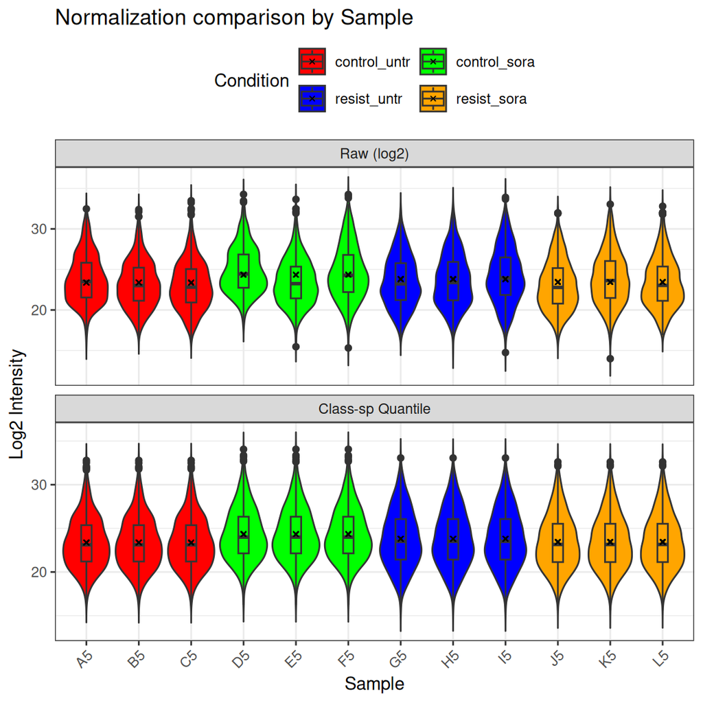

The density plots show how the class-specific strategy clearly retains group-specific patterns reflecting the raw biological variability.

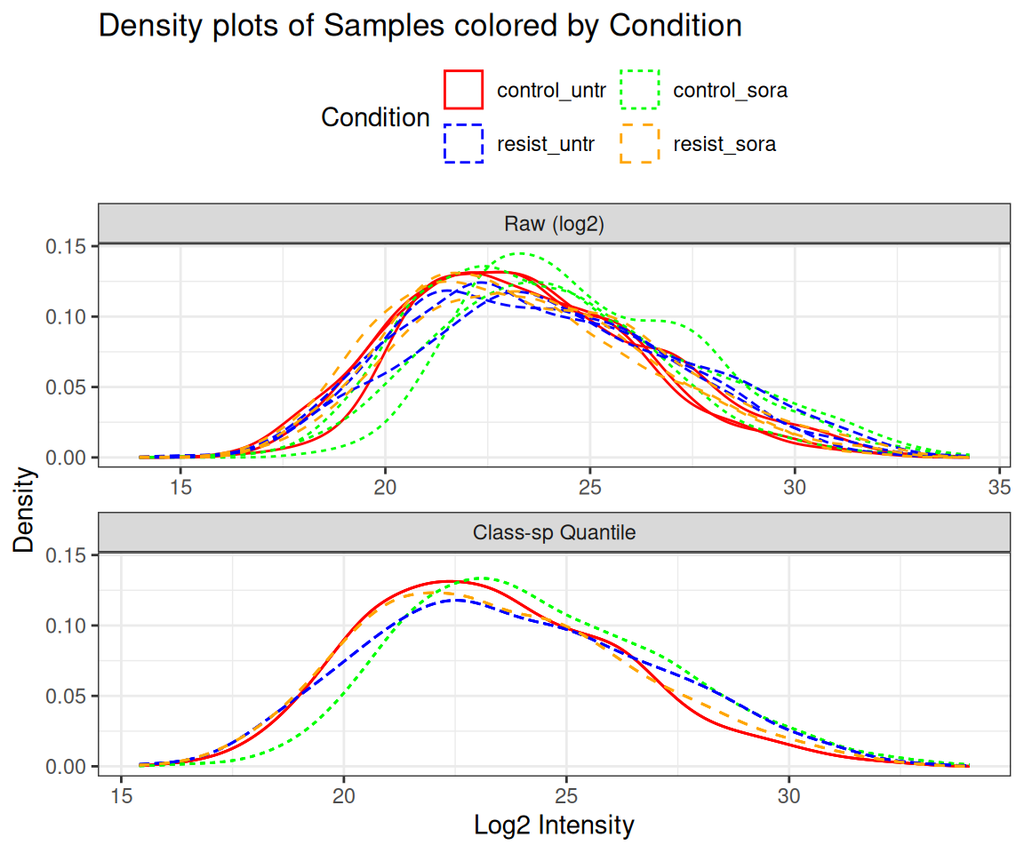

When visualizing individual protein intensities, the class-specific normalization strategy retains differences in group means observed in the unnormalized data, potentially preserving meaningful biological variation.

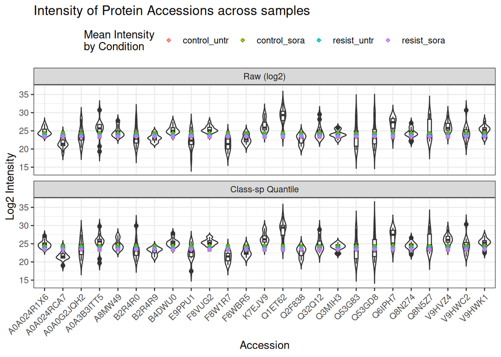

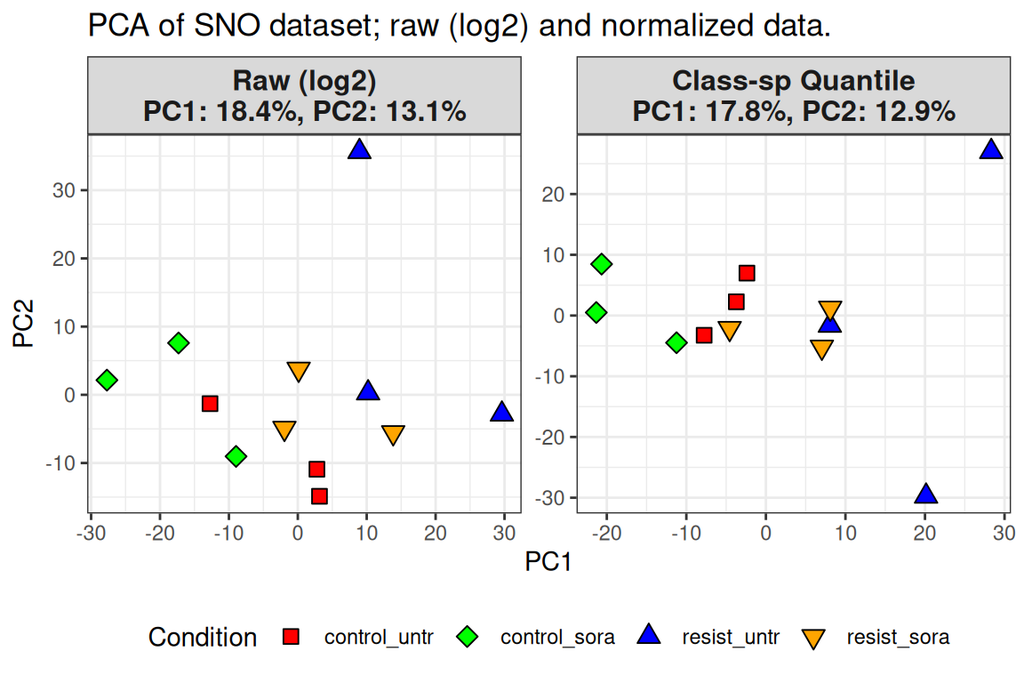

# Differential Protein Abundance Analysis with Limma

After normalization, differential abundance analysis was performed using the limma package, which fits a linear model to each protein and tests the specified contrasts. In this study, all pairwise combinations between the four experimental conditions (defined by cell line and treatment) were included as contrasts. The results were filtered using a p-value threshold of < 0.05, and protein metadata were integrated to facilitate biological interpretation.

Below is a sample of the intermediate results.

```
##    Accession     logFC  AveExpr         t      P.Value adj.P.Val          B
## 1     Q53GD8 -7.306464 23.91006 -4.752424 0.0004432342 0.1659057 -0.1782896
## 2 A0A024RC29  5.912111 25.82451  4.693271 0.0004911759 0.1659057 -0.2516082
## 4 A0A024R071 -9.469975 22.36742 -5.464069 0.0005360442 0.1659057 -0.8181633
## 5     V9HWF4  5.222815 25.58280  4.494848 0.0006954895 0.1722032 -0.5021846
## 6     Q53EY8  6.830787 23.03904  4.145011 0.0015516069 0.3017747 -1.2146135
##                  Contrast                      Protein_name       Uniprot_ID
## 1 resist_sora-resist_untr          Peptidylprolyl isomerase     Q53GD8_HUMAN
## 2 resist_sora-resist_untr      Desmocollin 3, isoform CRA_b A0A024RC29_HUMAN
## 4 resist_sora-resist_untr Nucleoporin 155kDa, isoform CRA_a A0A024R071_HUMAN
## 5 resist_sora-resist_untr           Phosphoglycerate kinase     V9HWF4_HUMAN
## 6 resist_sora-resist_untr     Nucleoside-diphosphate kinase     Q53EY8_HUMAN
##   Gene_id    Symbol Coverage n_Uniq_Pept n_AAs  MW_kDa calc_pI n_contrast
## 1      NA      <NA>    89.29           5   224  25.188    9.42          3
## 2    1825      DSC3    22.66           1   896  99.892    6.10          3
## 4    9631    NUP155    19.19           1  1391 155.100    6.16          3
## 5    5230 HEL-S-68p    68.59          14   417  44.586    8.10          4
## 6      NA      <NA>    38.66           2   194  21.605    8.85          3
##   abs_Change log10_pvalue CombinedScore
## 1   4.752424     3.353367     107526.12
## 2   4.693271     3.308763     105451.59
## 4   5.464069     3.270799     159579.87
## 5   4.494848     3.157709     173622.69
## 6   4.145011     2.809218      29177.53
```

```
##                    Contrast n_sig n_adj
## 1   resist_sora-resist_untr    71     0
## 2  resist_sora-control_sora   131     0
## 3  resist_sora-control_untr    56     0
## 4  resist_untr-control_sora   166     0
## 5  resist_untr-control_untr    75     1
## 6 control_sora-control_untr   102     0
```

Before protein-detailed visualization of the overall results and to prioritize biologically relevant candidates, a composite Combined Score was calculated for each protein, integrating effect size (t-statistic), p-value and the number of contrasts in which the protein was significant, as well as basic protein features (coverage, molecular weight):

`CombinedScore = abs(t) × log10(p-value) × n_contrast × Coverage × MW_kDa`

This score was used to sort proteins in those visualizations that include several contrasts, highlighting those of relevance. Here, color scale indicates Fold Change, while size is proportional to p-value significance.

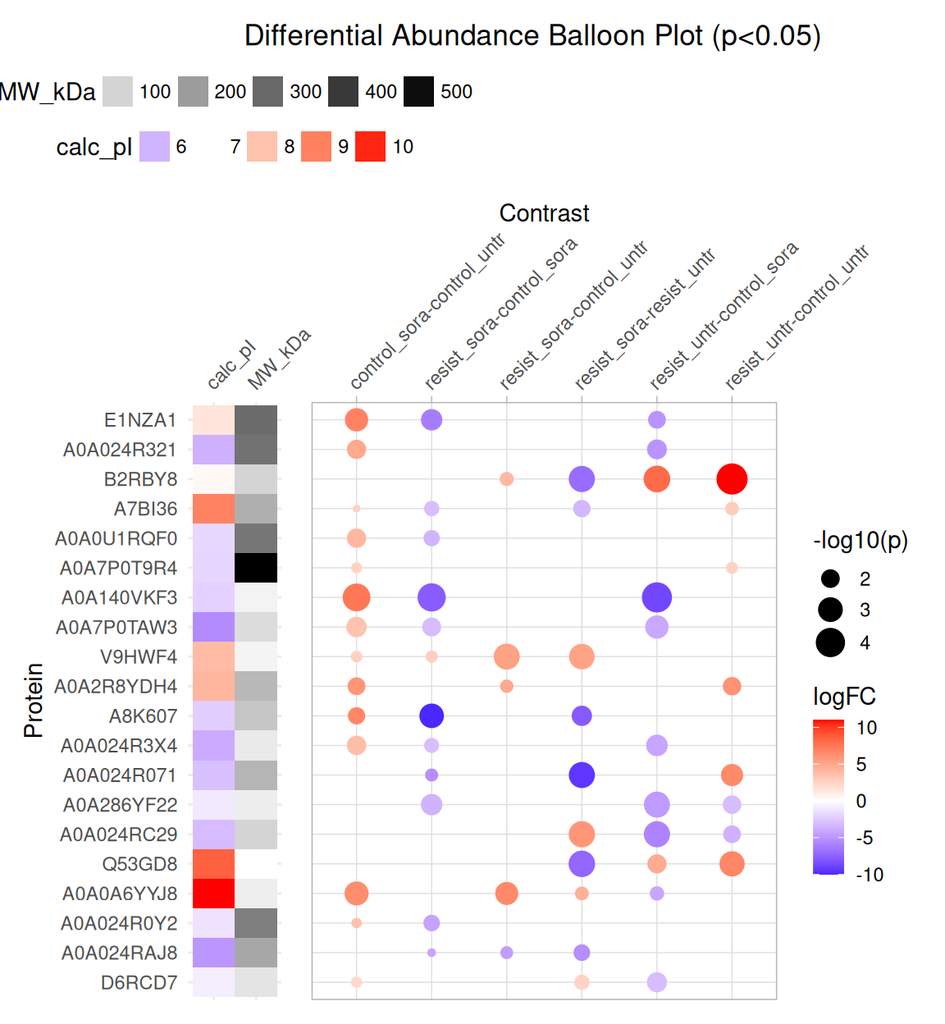

These results show strong candidates like ENPP1 (ectonucleotide pyrophosphatase/phosphodiesterase 1), peptidylprolyl isomerase, and fatty acid synthase, all of which have been implicated in cancer biology, stress responses, or redox regulation. The corresponding list of proteins is the following:

```
##                                                      Protein_name  Accession
## 1  Peroxisome proliferator activated receptor interacting complex     E1NZA1
## 2      Filamin B, beta (Actin binding protein 278), isoform CRA_a A0A024R321
## 3      ectonucleotide pyrophosphatase/phosphodiesterase 1 (ENPP1)     B2RBY8
## 4                                          p180/ribosome receptor     A7BI36
## 5                                             Fatty acid synthase A0A0U1RQF0
## 6                              Cytoplasmic dynein 1 heavy chain 1 A0A7P0T9R4
## 7                      Testis tissue sperm-binding protein Li 70n A0A140VKF3
## 8                                   15S Mg(2+)-ATPase p97 subunit A0A7P0TAW3
## 9                                         Phosphoglycerate kinase     V9HWF4
## 10                                        Uncharacterized protein A0A2R8YDH4
## 11                                              exportin 7 (XPO7)     A8K607
## 12                                              60 kDa chaperonin A0A024R3X4
## 13                              Nucleoporin 155kDa, isoform CRA_a A0A024R071
## 14                             D-3-phosphoglycerate dehydrogenase A0A286YF22
## 15                                   Desmocollin 3, isoform CRA_b A0A024RC29
## 16                                       Peptidylprolyl isomerase     Q53GD8
## 17                       Putative RNA-binding protein Luc7-like 2 A0A0A6YYJ8
## 18                                       Acetyl-CoA carboxylase 1 A0A024R0Y2
## 19 IQ motif containing GTPase activating protein 2, isoform CRA_b A0A024RAJ8
## 20                               75 kDa glucose-regulated protein     D6RCD7
```

# KEGG Pathway Enrichment with ClusterProfiler

To investigate the functional implications of the observed proteomic alterations, KEGG pathway enrichment analysis was performed using ClusterProfiler. Enrichment was assessed using the full list of genes in the KEGG database as background.

The table below summarizes the number of significantly enriched pathways (p < 0.05) detected for each comparison.

```
##                    Contrast n_sig n_adj
## 1   resist_sora-resist_untr     9     3
## 2  resist_sora-control_sora    26     5
## 3  resist_sora-control_untr     5     1
## 4  resist_untr-control_sora    28     7
## 5  resist_untr-control_untr    14     0
## 6 control_sora-control_untr    24     4
```

On the next figure, the most significantly enriched pathways (by adjusted p-value) are displayed along with the contrasts that support such enrichment. Notably, Biosynthesis of amino acids is consistently enriched.

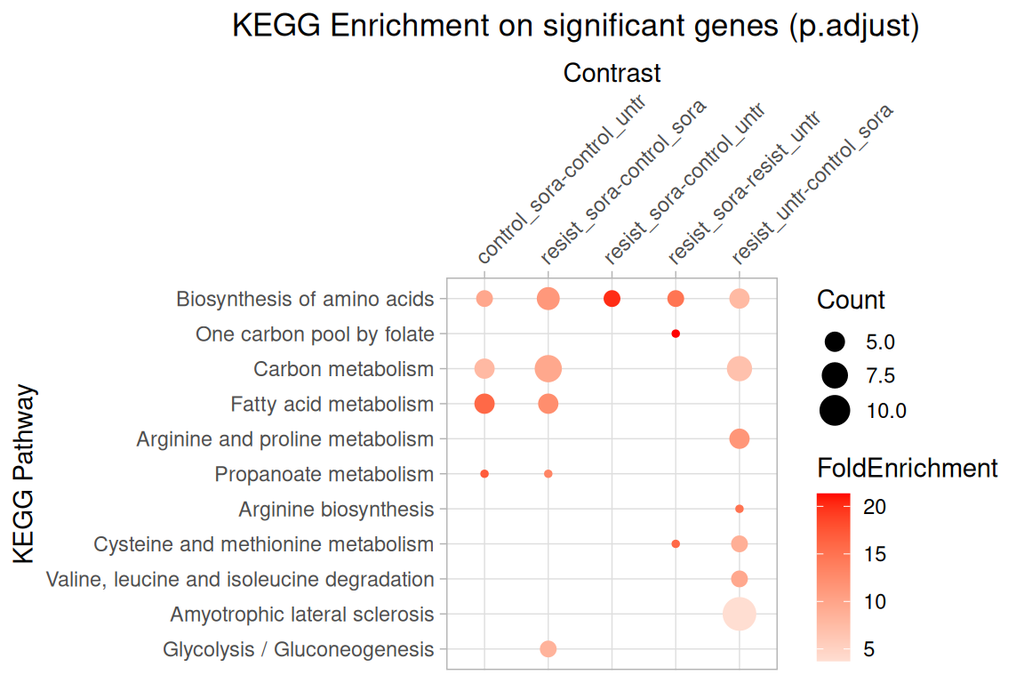

We may also visualize the genes that are responsible for the enrichment of these pathways.

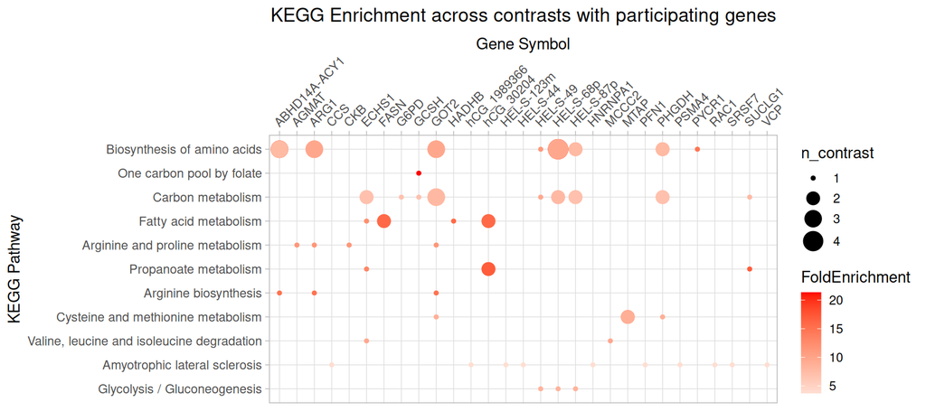

Filtering results by unadjusted p-value yielded a substantially larger set of enriched pathways. To focus on more physiologically relevant insights, disease-related pathways were excluded from the following visualization, and a display limit was applied to the number of pathways shown.

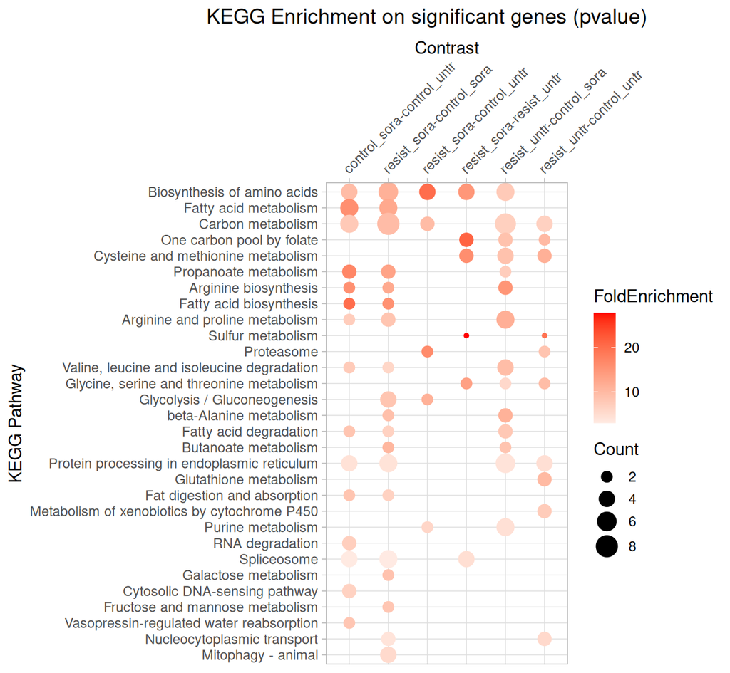

To finalize, KEGG pathway enrichment was examined in two specific contrasts. In the resulting plots, color (red/blue) represents the direction of the limma differential abundance fold change (FC), while the shape encodes a combination of differential abundance (FC) and KEGG fold enrichment (FE). Since FE values are always positive, the shift in shape size primarily reflects the direction and magnitude of the FC.

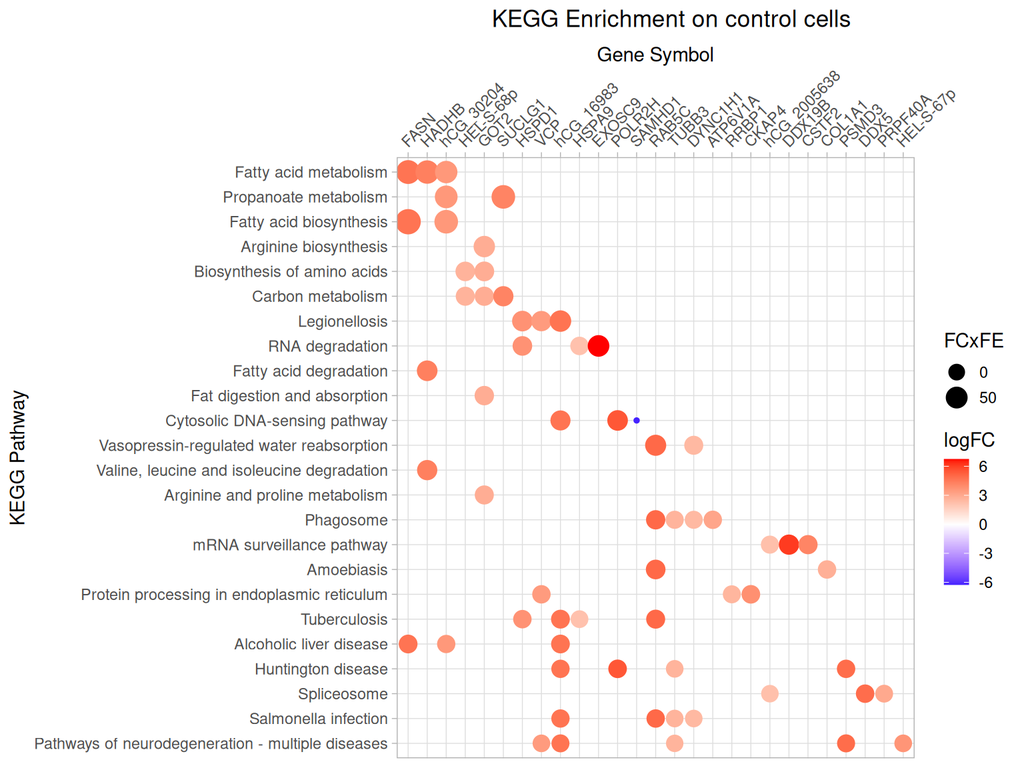

In this case, the negative of FC was used to emphasize the negatively regulated proteins.

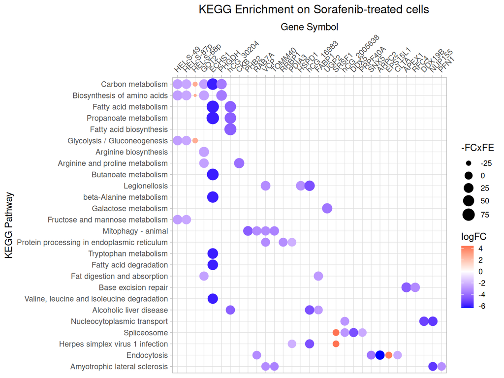

A shared set of pathways appears counterbalanced between the two contrasts, as their constituent proteins primarily display opposite fold change directions in each comparison:

```
##  [1] "Fatty acid metabolism"
##  [2] "Carbon metabolism"
##  [3] "Propanoate metabolism"
##  [4] "Biosynthesis of amino acids"
##  [5] "Fatty acid biosynthesis"
##  [6] "Arginine biosynthesis"
##  [7] "Protein processing in endoplasmic reticulum"
##  [8] "Fatty acid degradation"
##  [9] "Fat digestion and absorption"
## [10] "Valine, leucine and isoleucine degradation"
## [11] "Arginine and proline metabolism"
## [12] "Spliceosome"
```

Likewise, eight shared proteins exhibit opposite regulation between the two contrasts, highlighting potential key modulators of the differential response:

```
## [1] "15S Mg(2+)-ATPase p97 subunit (VCP)"
## [2] "Acetyl-CoA carboxylase 1 (hCG_30204)"
## [3] "Aspartate aminotransferase (GOT2)"
## [4] "DEAD box protein 5 (DDX5)"
## [5] "p180/ribosome receptor (RRBP1)"
## [6] "Pre-mRNA-processing factor 40 homolog A (PRPF40A)"
## [7] "RNA helicase (hCG_2005638)"
## [8] "RNA helicase (DDX19B)"
```